# Ford GoBike System Data

## Introduction

> This document explores a dataset with information about individual rides made in a bike-sharing system covering the greater San Francisco Bay area for Just a month in the year 2019. It countains about 183,000 rides with information about their starting and ending location, the duration of the rides and the rider's infromation.

## Preliminary Wrangling

```python
# import all packages and set plots to be embedded inline
import numpy as np
import pandas as pd
import matplotlib.pyplot as plt
import seaborn as sb

import time

%matplotlib inline
```

```python
# Load in the dataset into a pandas Dataframe and performing some statistics
gobike = pd.read_csv("201902-fordgobike-tripdata.csv")
gobike.tail()
```

|  | duration_sec | start_time | end_time | start_station_id | start_station_name | start_station_latitude | start_station_longitude | end_station_id | end_station_name | end_station_latitude | end_station_longitude | bike_id | user_type | member_birth_year | member_gender | bike_share_for_all_trip |
| --- | --- | --- | --- | --- | --- | --- | --- | --- | --- | --- | --- | --- | --- | --- | --- | --- |
| 183407 | 480 | 2019-02-01 00:04:49.7240 | 2019-02-01 00:12:50.0340 | 27.0 | Beale St at Harrison St | 37.788059 | -122.391865 | 324.0 | Union Square (Powell St at Post St) | 37.788300 | -122.408531 | 4832 | Subscriber | 1996.0 | Male | No |
| 183408 | 313 | 2019-02-01 00:05:34.7440 | 2019-02-01 00:10:48.5020 | 21.0 | Montgomery St BART Station (Market St at 2nd St) | 37.789625 | -122.400811 | 66.0 | 3rd St at Townsend St | 37.778742 | -122.392741 | 4960 | Subscriber | 1984.0 | Male | No |
| 183409 | 141 | 2019-02-01 00:06:05.5490 | 2019-02-01 00:08:27.2200 | 278.0 | The Alameda at Bush St | 37.331932 | -121.904888 | 277.0 | Morrison Ave at Julian St | 37.333658 | -121.908586 | 3824 | Subscriber | 1990.0 | Male | Yes |
| 183410 | 139 | 2019-02-01 00:05:34.3600 | 2019-02-01 00:07:54.2870 | 220.0 | San Pablo Ave at MLK Jr Way | 37.811351 | -122.273422 | 216.0 | San Pablo Ave at 27th St | 37.817827 | -122.275698 | 5095 | Subscriber | 1988.0 | Male | No |
| 183411 | 271 | 2019-02-01 00:00:20.6360 | 2019-02-01 00:04:52.0580 | 24.0 | Spear St at Folsom St | 37.789677 | -122.390428 | 37.0 | 2nd St at Folsom St | 37.785000 | -122.395936 | 1057 | Subscriber | 1989.0 | Male | No |

```python
gobike.describe()
```

|  | duration_sec | start_station_id | start_station_latitude | start_station_longitude | end_station_id | end_station_latitude | end_station_longitude | bike_id | member_birth_year |
| --- | --- | --- | --- | --- | --- | --- | --- | --- | --- |
| count | 183412.000000 | 183215.000000 | 183412.000000 | 183412.000000 | 183215.000000 | 183412.000000 | 183412.000000 | 183412.000000 | 175147.000000 |
| mean | 726.078435 | 138.590427 | 37.771223 | -122.352664 | 136.249123 | 37.771427 | -122.352250 | 4472.906375 | 1984.806437 |
| std | 1794.389780 | 111.778864 | 0.099581 | 0.117097 | 111.515131 | 0.099490 | 0.116673 | 1664.383394 | 10.116689 |
| min | 61.000000 | 3.000000 | 37.317298 | -122.453704 | 3.000000 | 37.317298 | -122.453704 | 11.000000 | 1878.000000 |
| 25% | 325.000000 | 47.000000 | 37.770083 | -122.412408 | 44.000000 | 37.770407 | -122.411726 | 3777.000000 | 1980.000000 |
| 50% | 514.000000 | 104.000000 | 37.780760 | -122.398285 | 100.000000 | 37.781010 | -122.398279 | 4958.000000 | 1987.000000 |
| 75% | 796.000000 | 239.000000 | 37.797280 | -122.286533 | 235.000000 | 37.797320 | -122.288045 | 5502.000000 | 1992.000000 |
| max | 85444.000000 | 398.000000 | 37.880222 | -121.874119 | 398.000000 | 37.880222 | -121.874119 | 6645.000000 | 2001.000000 |

```python
gobike.info()
```

```
<class 'pandas.core.frame.DataFrame'>
RangeIndex: 183412 entries, 0 to 183411
Data columns (total 16 columns):
 #   Column                   Non-Null Count   Dtype
---  ------                   --------------   -----
 0   duration_sec             183412 non-null  int64
 1   start_time               183412 non-null  object
 2   end_time                 183412 non-null  object
 3   start_station_id         183215 non-null  float64
 4   start_station_name       183215 non-null  object
 5   start_station_latitude   183412 non-null  float64
 6   start_station_longitude  183412 non-null  float64
 7   end_station_id           183215 non-null  float64
 8   end_station_name         183215 non-null  object
 9   end_station_latitude     183412 non-null  float64
 10  end_station_longitude    183412 non-null  float64
 11  bike_id                  183412 non-null  int64
 12  user_type                183412 non-null  object
 13  member_birth_year        175147 non-null  float64
 14  member_gender            175147 non-null  object
 15  bike_share_for_all_trip  183412 non-null  object
dtypes: float64(7), int64(2), object(7)
memory usage: 22.4+ MB
```

### Structure of the dataset

> There are 183412 bike rides for the year 2019 in the month of Febraury in the dataset with 16 columns Most of the data are numeric in nature with the others being categorical (user_type, member_gender, bike_share_for all_trip)

## Data Wrangling

> The dataset does not look entriely clean for to explore, thus, i will be performing some data wrangling on the dataset and doing data engineering to get most out of the data for to explore

#### Converting the duration in seconds to minutes

```python
# Converting the duration in second to minutes to better get a definition of th duraton spend for a ride.
def convert_to_min(sec):
    """
    takes in an integer as input.
    Converts the seconds to minutes
    Returns an integer.
    """
    return int(sec/60)
gobike["duration_min"] = gobike["duration_sec"].apply(convert_to_min)
```

#### Dealing with start_time and end_time data

```python
# converting the time data from object to datetime to better perform analysis on.

gobike["start_time"] = pd.to_datetime(gobike["start_time"])
gobike["end_time"] = pd.to_datetime(gobike["end_time"])
```

```python
#extracting the day and hour for the start and end time..

gobike["start_time_day"] = gobike.start_time.dt.day_name()
gobike["end_time_day"] = gobike.end_time.dt.day_name()
gobike["start_time_hour"] = gobike.start_time.dt.hour
gobike["end_time_hour"] = gobike.end_time.dt.hour
```

#### Dropping columns with null: start_station_id, start_station_name, end_station_id,end_station_name

> There are null columns and since i am majorly performing exploration i would be dropping the null columns to better perform analysis

```python
gobike = gobike.dropna(axis=0, subset=["start_station_id"])
```

#### Calculating the distance between the start and end station location

```python
# Using the great circle or the Orthodromic distance to get the distance
# using the latitudes and logitudes of the start and end station location

from math import radians, cos, sin,asin, sqrt, atan2
def distance_cal(cols):

    """
    This function calculates the distance given a starting latitude and logitude
    and ending latitude and logitude in a list as inputs.
    It uses the Great circle or Orthodromic distance formula.
    It returns the distance in 2 d.p

    """
    r = 6373
    start_lat = cols[0]
    start_long = cols[1]
    end_lat = cols[2]
    end_long = cols[3]

    start_lat, start_long, end_lat, end_long = (radians(start_lat),radians(start_long),radians(end_lat),radians(end_long))


    dist_lat = end_lat - start_lat
    dist_long = end_long - start_long

    a = sin(dist_lat/2)**2 + cos(start_lat)*cos(end_lat)*sin(dist_long/2)**2

    c = 2 * atan2(sqrt(a), sqrt(1-a))

    return round((c*r),2)

gobike["distance"] = gobike[["start_station_latitude","start_station_longitude",
                           "end_station_latitude","end_station_longitude"]].apply(distance_cal,axis=1)
```

```python
gobike.distance.describe()
```

```
count    183215.000000
mean          1.691824
std           1.097969
min           0.000000
25%           0.910000
50%           1.430000
75%           2.230000
max          69.490000
Name: distance, dtype: float64
```

### Getting the Ages of the bike rider

```python
#The data was taken in 2019, so getting their ages..
gobike["Age"]  = gobike["member_birth_year"].apply(lambda x: 2019 - x)
```

```python
gobike.info()
```

```
<class 'pandas.core.frame.DataFrame'>
Int64Index: 183215 entries, 0 to 183411
Data columns (total 23 columns):
 #   Column                   Non-Null Count   Dtype
---  ------                   --------------   -----
 0   duration_sec             183215 non-null  int64
 1   start_time               183215 non-null  datetime64[ns]
 2   end_time                 183215 non-null  datetime64[ns]
 3   start_station_id         183215 non-null  float64
 4   start_station_name       183215 non-null  object
 5   start_station_latitude   183215 non-null  float64
 6   start_station_longitude  183215 non-null  float64
 7   end_station_id           183215 non-null  float64
 8   end_station_name         183215 non-null  object
 9   end_station_latitude     183215 non-null  float64
 10  end_station_longitude    183215 non-null  float64
 11  bike_id                  183215 non-null  int64
 12  user_type                183215 non-null  object
 13  member_birth_year        174952 non-null  float64
 14  member_gender            174952 non-null  object
 15  bike_share_for_all_trip  183215 non-null  object
 16  duration_min             183215 non-null  int64
 17  start_time_day           183215 non-null  object
 18  end_time_day             183215 non-null  object
 19  start_time_hour          183215 non-null  int64
 20  end_time_hour            183215 non-null  int64
 21  distance                 183215 non-null  float64
 22  Age                      174952 non-null  float64
dtypes: datetime64[ns](2), float64(9), int64(5), object(7)
memory usage: 33.5+ MB
```

### What is/are the main feature(s) of interest in your dataset?

> I'm interested in features that tell the duration of bike rides and features that can affect the duration of bike rides

### What features in the dataset do you think will help support your investigation into your feature(s) of interest?

> I expect that the distance betweeen the start and end of the bike ride should strongly affect the duration of bike ride: the longer the distance the longer the time taken to finish the ride.. I also think that gender, user_type, member_birth_year (older people might take a longer time).. will have effects on the duration of bike ride..

## Univariate Exploration

> In this section, I will be exploring the variables majorly the main feature as explained ealier and the other features that help support the investigation.

#### How is the main feature of interest - duration_min distributed?

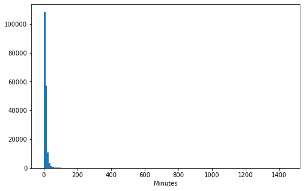

```python
# start with a standard-scaled plot

bins = np.arange(0, 1450+10,10)

plt.figure(figsize=[8, 5])
plt.hist(data = gobike, x = 'duration_min',bins=bins)
plt.xlabel('Minutes')
plt.show()
```

It looks like there were very long distances carried out, which i will check later

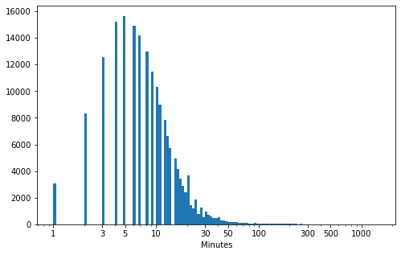

```python
# This is a long tailed distribution skewed to the right, performing a log transformation on the data

# bin size to better see the data
log_binsize = 0.025
bins = 10 ** np.arange(0, np.log10(gobike["duration_min"].max())+log_binsize,log_binsize)

plt.figure(figsize=[8, 5])
plt.hist(data = gobike, x = 'duration_min',bins=bins)
plt.xscale("log")
plt.xticks([1,3,5,10,30,50,100,300,500,1000], ["1","3","5","10","30","50","100","300","500","1000"])
plt.xlabel('Minutes')
plt.show()
```

The duration of ride is a long tailed distribution skewed to the right, with majority of the with a low duration, to get a better understanding of the data and how it distributed, performing a log transformation on the data, it is seen that about 80% of the rides range from 3 to 25 minutes...

#### How is the distance (km) feature distributed?

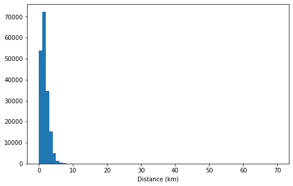

```python
# start with a standard-scaled plot

bins = np.arange(0, 70+1,1)

plt.figure(figsize=[8, 5])
plt.hist(data = gobike, x = 'distance',bins=bins)
plt.xlabel("Distance (km)")
plt.show()
```

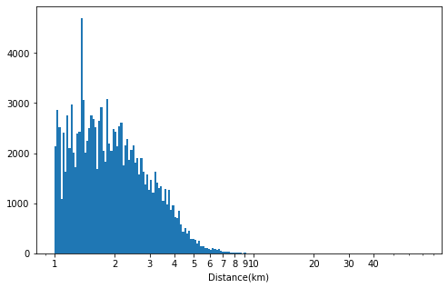

```python
# This is a long tailed distribution skewed to the right, performing a log transformation on the data
log_binsize = 0.01
bins = 10 ** np.arange(0, np.log10(gobike["distance"].max())+log_binsize,log_binsize)

plt.figure(figsize=[8, 5])
plt.hist(data = gobike, x = 'distance',bins=bins)
plt.xscale("log")
plt.xticks([1,2,3,4,5,6,7,8,9,10,20,30,40], ["1","2","3","4","5","6","7","8","9","10","20","30","40"])
plt.xlabel("Distance(km)")
plt.show()
```

This is seen to have a nearly similar distribution as the duration, this can suppose that this is a strong predictor of the time taken for each ride. There is a unique spike of the distance around 1.3 to 1.6 km

#### Looking at the other variables that seem to be good predictors

##### Starting with the start and end days and hours

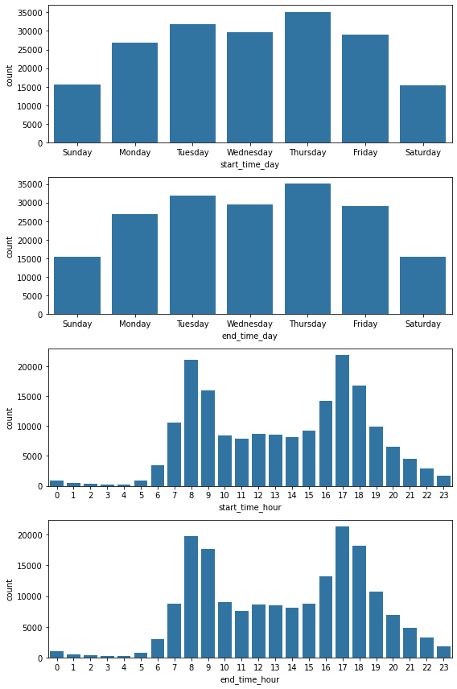

```python
fig, ax = plt.subplots(nrows=4, figsize=[8,12])

order = ["Sunday", "Monday", "Tuesday", "Wednesday", "Thursday", "Friday", "Saturday"]
default_color = sb.color_palette()[0]
sb.countplot(data = gobike, x = "start_time_day",color = default_color, ax = ax[0], order = order)
sb.countplot(data = gobike, x = "end_time_day",color = default_color, ax = ax[1], order=order)
sb.countplot(data = gobike, x = "start_time_hour",color = default_color, ax = ax[2])
sb.countplot(data = gobike, x = "end_time_hour",color = default_color, ax = ax[3])

plt.tight_layout()
```

From this data it is seen that people take rides mostly on Thursday and Teusdays and less rides on saturdays and sundays

##### Checking the effect of gender

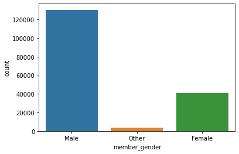

```python
sb.countplot(data=gobike, x="member_gender")
```

#### Looking at the Age Feature

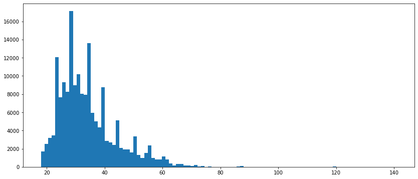

```python
plt.figure(figsize=(14,6))
plt.hist(data=gobike, x="Age",bins=100);
```

> From the chart, It is seen that most of the ages of the riders are between the ages 20 and 40.

> Also there are ages above 100, which seems absurd, but i will be leaving them for exploration sake

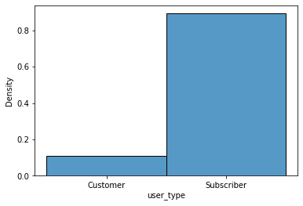

```python
sb.histplot(data=gobike, x="user_type", stat="density")
```

From this bar chart, It is seen that 90% of the riders are subcribers.

### Discuss the distribution(s) of your variable(s) of interest. Were there any unusual points? Did you need to perform any transformations?

> The duration in minutes took on large range of values and was greatly skewed to the right, I took a log transformation of the data, Under this transformation, the data took almost a normal distribution most of the rides for about 3 to 20 minutes

### Of the features you investigated, were there any unusual distributions? Did you perform any operations on the data to tidy, adjust, or change the form of the data? If so, why did you do this?

> In investigating the Age feature, it was right skewed which was not expected, there were ages greater than age 100, these data were left for exploration purposes

## Bivariate Exploration

> In this section, I will be investigating the relationships between pairs of variables in the data.

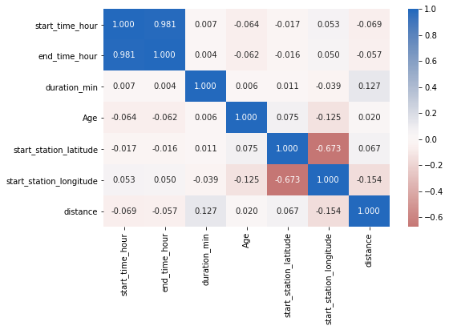

```python
# correlation plot

num_cols = ["start_time_hour", "end_time_hour", "duration_min","Age",
            "start_station_latitude","start_station_longitude","distance"]

plt.figure(figsize = [8, 5])
sb.heatmap(gobike[num_cols].corr(), annot = True, fmt = '.3f',
           cmap = 'vlag_r', center = 0)
plt.show()
```

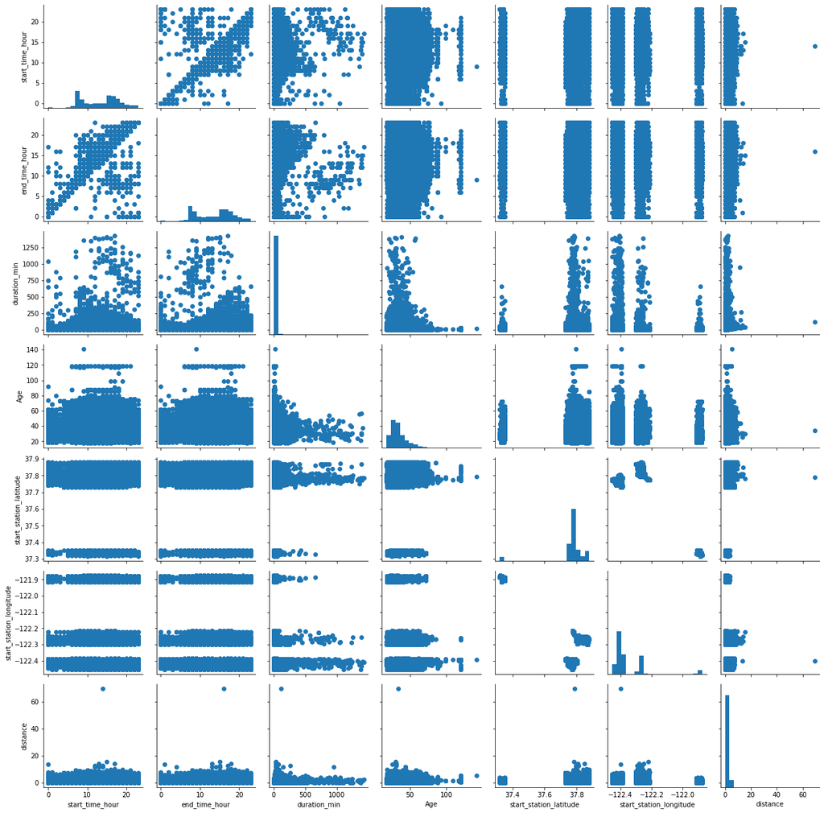

```python
g = sb.PairGrid(data = gobike, vars = num_cols)
g = g.map_diag(plt.hist, bins = 20);
g.map_offdiag(plt.scatter)
```

From these two plots there seems to be no strong relationship amongst the features, other than the tart and end times and latitudes and logittudes.

There is a little bit of relationship between the distance and the duration features which is explored.

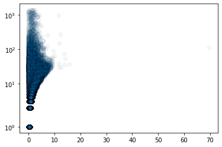

```python
## Taking a closer look on the relationship between the duration of ride and distance
plt.scatter(x = "distance", y = "duration_min", data = gobike, s=40, alpha=0.05, edgecolors="k")
#plt.xscale("log")
plt.yscale("symlog")
```

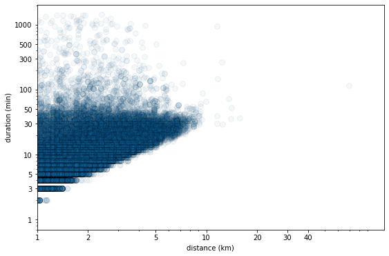

```python
# Because of the nature of these features as seen the in the univariate exploration a log transformation is done on both the
# duration and distance features.
fig, ax = plt.subplots(figsize = (9, 6))
ax.scatter(x = "distance", y = "duration_min",data = gobike, s=60, alpha=0.05, edgecolors="k")

# Set logarithmic scale on the both variables
ax.set_xscale("log")
ax.set_yscale("log")
plt.yticks([1,3,5,10,30,50,100,300,500,1000], ["1","3","5","10","30","50","100","300","500","1000"]);
plt.xticks([1,2,5,10,20,30,40], ["1","2","5","10","20","30","40"]);

plt.xlabel("distance (km)")
plt.ylabel("duration (min)");
```

There seems to be a relationship between the time spent and the distance covered but it is not strong.

#### What is the relationship between the Gender of the riders and their duration of ride?

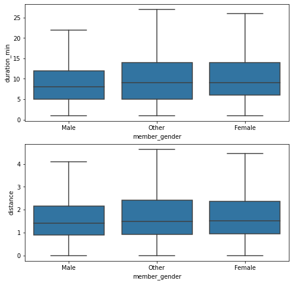

```python
#checking how gender affects....

plt.figure(figsize = [8, 8])

# subplot 1: color vs cut
plt.subplot(2, 1, 1)
colour = sb.color_palette()[0]
sb.boxplot(x= gobike["member_gender"], y = gobike["duration_min"],color=colour, showfliers=False)

# subplot 2: clarity vs. cut
ax = plt.subplot(2, 1, 2)
sb.boxplot(x= gobike["member_gender"], y = gobike["distance"],color=colour, showfliers=False)
```

#### What is the duration of the trips for different days?

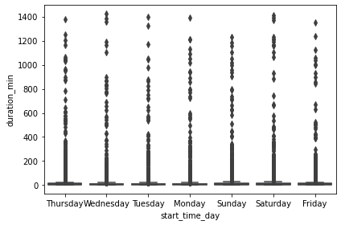

```python
colour = sb.color_palette()[0]
sb.boxplot(x= gobike["start_time_day"], y = gobike["duration_min"],color=colour)
plt.tight_layout()
```

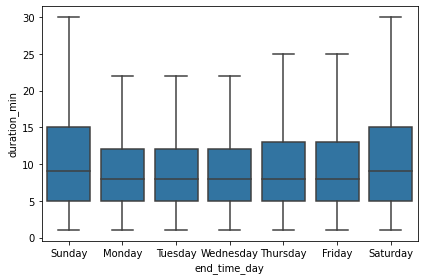

```python
# removing the fliers to see how they are well distributed
colour = sb.color_palette()[0]
order = ["Sunday", "Monday", "Tuesday", "Wednesday", "Thursday", "Friday", "Saturday"]
sb.boxplot(x= gobike["end_time_day"], y = gobike["duration_min"],color=colour, showfliers=False, order = order)
plt.tight_layout()
```

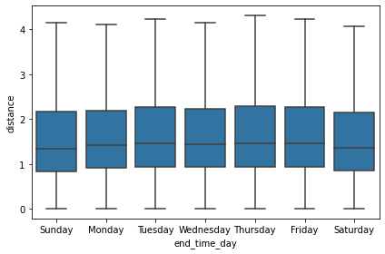

```python
colour = sb.color_palette()[0]
order = ["Sunday", "Monday", "Tuesday", "Wednesday", "Thursday", "Friday", "Saturday"]
sb.boxplot(x= gobike["end_time_day"], y = gobike["distance"],color=colour, showfliers=False, order=order)
plt.tight_layout()
```

From this data it is seen that the days when people don't actually take rides are the times when there are longer time for their rides

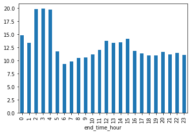

```python
gobike.groupby("end_time_hour").mean()["duration_min"].plot.bar()
```

#### Trend of the ages with the duration of ride

Dividing the ages into decades to understand the data better, and looking at the distribution with the duration.

```python
### Binning the ages
gobike["age_by_decade"] = pd.cut(gobike["Age"],
                                 bins=[10,29,39,49,59,60,150], labels = ["Teens","20s","30s","40s","50s","Old"])
```

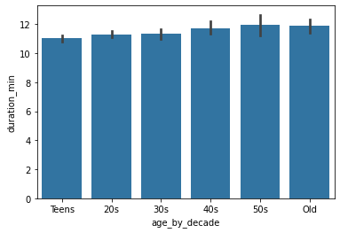

```python
colour = sb.color_palette()[0]

sb.barplot(x = gobike["age_by_decade"],y= gobike["duration_min"],color=colour)
```

As the age increases, it seen that more time is spent with the rides

Relationship between the duration of ride and the user type

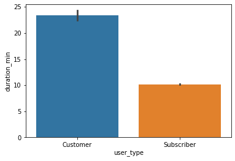

```python
#relationship between  and subscriber
sb.barplot(x ="user_type",y = "duration_min", data=gobike )
```

Apparently more customers take longer durations to ride.

#### How is the gender distributed amongst the Ages?

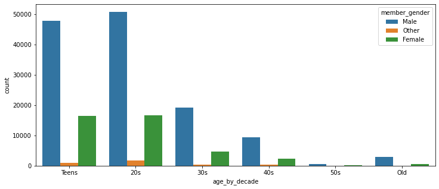

```python
plt.figure(figsize=[12,5])
sb.countplot(x = "age_by_decade", hue="member_gender",data=gobike)
```

It is seen that male gender dominates, but it is better to use the right proportion for a correct evaluation

#### Having a right proportion of the data

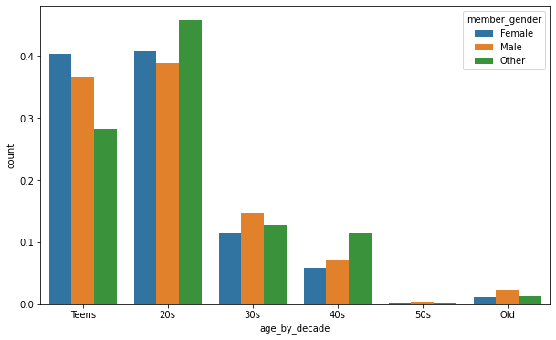

```python
# Get the percentage proportion of each gender type in th age group
gender_by_age = gobike.groupby(["age_by_decade","member_gender"]).count()["duration_min"]/gobike.groupby("member_gender").count()["duration_min"]
gender_by_age = gender_by_age.reset_index(name="count")


plt.figure(figsize = (10,6))
sb.barplot(x="age_by_decade", y = "count", hue="member_gender", data = gender_by_age);
```

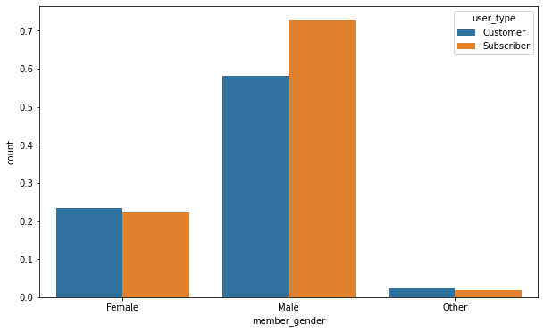

```python
# Get the percentage proportion of each gender type in th age group
user_by_gender = gobike.groupby(["member_gender","user_type"]).count()["duration_min"]/gobike.groupby("user_type").count()["duration_min"]
user_by_gender = user_by_gender.reset_index(name="count")


plt.figure(figsize = (10,6))
sb.barplot(x="member_gender", y = "count", hue="user_type", data = user_by_gender);
```

From this graph, there are lesser female subscribers and more male subscribers in with the gobike rider company

### Talk about some of the relationships you observed in this part of the investigation. How did the feature(s) of interest vary with other features in the dataset?

The duration (min) has a not too strong relationship with the distance covered as i proposed earlier, and i was not that surprised as routes passed to get to destinations would have been different and other factors could have affected them, so i further investigated the dataset. I found out that females tend to spend longer time with rides than men.

Saturdays and Sundays seems to be days of longer rides and even with shorter distances, so the days had an effect on the duration spent for the rides

It was also observed that older people tend to spend more time with the rides, although this was not too distinctive, it sure serves as a determinant in the duration spent.

## Multivariate Exploration

> Create plots of three or more variables to investigate your data even further. Make sure that your investigations are justified, and follow from your work in the previous sections.

#### How is the distribution of the trip duration for the different users for the days of the week?

Because of the data is not normalized, i will be normalizing most of the charts done to get more accurate data.

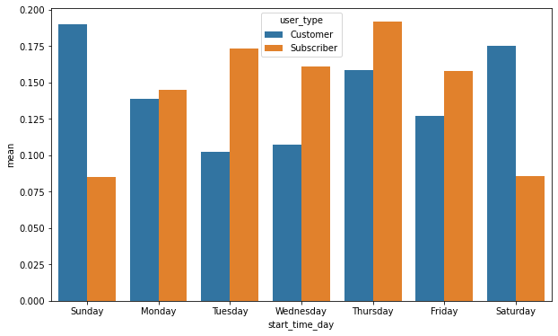

```python
user_by_day = gobike.groupby(["start_time_day","user_type"]).sum()["duration_min"]/gobike.groupby("user_type").sum()["duration_min"]
user_by_day = user_by_day.reset_index(name="mean")
plt.figure(figsize = (10,6))
sb.barplot(x="start_time_day", y = "mean", hue="user_type", data = user_by_day, order = order);
```

It is found that during the weekend, more of customers ride for longer durations, where subscribers take the lead in riding for longer durations during weekdays

Looking at it from hours of the day:

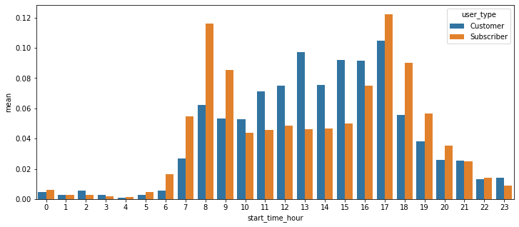

```python
user_by_day = gobike.groupby(["start_time_hour","user_type"]).sum()["duration_min"]/gobike.groupby("user_type").sum()["duration_min"]
user_by_day = user_by_day.reset_index(name="mean")
user_by_gender
plt.figure(figsize = (12,5))
sb.barplot(x="start_time_hour", y = "mean", hue="user_type", data = user_by_day);
```

Customers take a longer ride duration during the afternoon hours compared to the subscribers.

### Talk about some of the relationships you observed in this part of the investigation. Were there features that strengthened each other in terms of looking at your feature(s) of interest?

> The days serve as one good factor for determining the duration of riders, now taking it further with the users_type, it was found that during this weekends the people that usually take longer rides are the customers and not the subscribers. It is usually the subscribers that use longer duration for the weekdays

### Were there any interesting or surprising interactions between features?

> It was surprising to find to see that non-subscribers are the ones that take longer rides during the afternoon, Subscribers participate in longer rides udring the morning and evening hours.

## Conclusions

> I found out that the days had an effect on the duration of ride, During the Weekends longer rides are usually taken than weekdays and also older people took longer duration of ride than the younger ones. With further analysis, i found out that non-subscribers took longer rides during the weekends than the subscribers.